# 3.2.3

### 3.2.3 Резонанс токов в параллельном контуре

Цель работы: исследование резонанса токов в параллельном колебательном контуре с изменяемой ёмкостью, включающее получение амплитудно-частотных и фазово-частотных характеристик, а также определение основных параметров контура.\ В работе используются: генератор сигналов, источник тока, нагруженный на параллельный колебательный контур с переменной ёмкостью, двулучевой осциллограф, цифровые вольтметры.\ Схема установки, на которой будем проводить исследование резонанса в электрическом контуре, изображена на Рис. 1.

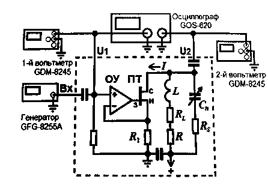

На осциллограф подается напряжение генератора $E$ напряжение на контуре $U$ Параллельно контуру включен источник тока на операционном усилителе. Ток затвора полевого транзистора мал, и можно считать: $$\tilde{I} = \frac{E}{R_1} =I_0 cos(\omega t+\varphi_0 ), I_0=\frac{E_0}{R_1} $$ Активное сопротивление конденсатора: $$R_s=\frac{tg(\delta)}{\omega C} , tg(\delta)<10^{-3}$$ Тогда суммарное сопротивление: $$R_\sum=R_L+R+R_S$$ Резонансная частота: $$\omega_0=\frac{1}{LC}$$ Волновое сопротивление: $$\rho=\sqrt{\frac{L}{C}}$$ Добротность: $$Q=\frac{\rho}{R_Σ} = \omega_0 \frac{L}{R_\sum} = \frac{1}{\omega_0 CR_\sum }$$

```python
import numpy as m
import pandas as pd
import plotly.express as px
import plotly.graph_objects as go
from plotly.subplots import make_subplots
from IPython.display import display, HTML
```

Установим напряжение генератора $E = 96 мВ$. Измерим и запишем в таблицу резонансные частоты $f_n$ и соответствующие им напряжения $U_n$ для контуров с семью различными емкостями $C_n$. Также будем фиксировать изменение напряжения с генератора. Последовательно вычислим все недостающие параметры: $L,\rho,Z_{рез},Q,R_\sum,R_{Smax},R_L$, и тоже запишем их в таблицу. по формулам: $$L = \frac{1}{(2\pi f_n)^2C_n}$$ $$\rho = \sqrt{\frac{L}{C}} $$ $$Z_{рез} = \frac{U_n R_1}{E}$$ $$Q=\frac{Z_{\text{рез}}}{\rho}$$ $$R_{\Sigma}=\frac{\rho}{Q}$$ $$R_{\Sigma}=R+R_{L}+R_{S}$$ $$R_{Smax}=10^{-3}\rho$$ $$R_{L}=R_{\Sigma}-R-R_{S}$$ А также погрешности: $$\sigma(\rho)=\frac{1}{2\sqrt{LC}}\sigma(L)$$ $$\sigma(Q)=\sigma(\rho)\frac{Z_{рез}}{\rho^2}$$ $$\sigma(R_{\Sigma})=\sqrt{\left(\frac{1}{Q}\right)^2(\sigma(\rho))^2+\left(\frac{\rho}{Q^2}\right)^2(\sigma(Q))^2}$$ $$\sigma(R_{L})=\sqrt{\left(\sigma(R_{\Sigma})\right)^2+\left(\sigma(R_{S})\right)^2}$$ $$\sigma(\langle{X}\rangle)=\sqrt{\frac{1}{42}\Sigma(X_{i}-\langle{X}\rangle)^2}$$

```python
data = pd.read_excel('3.2.3.xlsx').drop('Unnamed: 16',axis = 1)
scheme_char = data.iloc[:, 0:4].dropna()
R = 3.5 # в Омах
R_1 = 1008 # в Омах
def deviation_table(a):
    b = pd.DataFrame()
    b.loc['mean',a.name] = a.mean()
    b.loc['Random_deviation',a.name] = a.std()
    b.loc['Mean_square_deviation',a.name] = a.std()/a.size**0.5
    return b
def surgery(k,*num,asc = False):
    d = k.copy()
    a = d[d.iloc[:,0]<=1]
    b = d[d.iloc[:,0]>1]
    if len(num) == 1:
        a.loc[a.shape[0]+1,a.keys()[1]] = num[0]
        b.loc[d.shape[0]+1,b.keys()[1]] = num[0]
    elif len(num) == 2:
        a.loc[a.shape[0]+1,a.keys()[1]] = num[0]
        b.loc[d.shape[0]+1,b.keys()[1]] = num[1]
    #print(a, b)
    a = a.set_index(a.keys()[1])
    b = b.set_index(b.keys()[1])
    a = a.sort_index()
    b = b.sort_index()
    a = a.interpolate(method='from_derivatives')
    b = b.interpolate(method='from_derivatives')
    b = b.sort_index(ascending=asc)
    #print(a, b)
    return [a, b]
def domega(d,num = round(0.5**0.5,3)):
    a, b = surgery(d,num)
    return b.loc[num]-a.loc[num]
def surgery_2(k):
    d = k.copy()
    a = d[d.iloc[:,0]<=1]
    b = d[d.iloc[:,0]>1]
    a.iloc[:,1] = (a.iloc[:,2]-a.iloc[:,1])/a.iloc[:,2]
    b.iloc[:,1] = (b.iloc[:,2]+b.iloc[:,1])/b.iloc[:,2]
    #print(a, b)
    return pd.concat([b,a])

scheme_char['L_mcHn'] = (10**15)/(scheme_char.Cn_nF*(2*m.pi*scheme_char.fn)**2)
scheme_char['p'] = (scheme_char.L_mcHn*1000/scheme_char.Cn_nF)**0.5
scheme_char['Z рез'] = R_1*scheme_char.un_mV/scheme_char.en_mV
scheme_char['Q'] = scheme_char['Z рез']/scheme_char.p
scheme_char['R_sum'] = scheme_char.p/scheme_char.Q
scheme_char['R_s'] = scheme_char.p*10**-3
scheme_char['R_l'] = scheme_char.R_sum-scheme_char.R_s-R
scheme_dev = deviation_table(scheme_char.L_mcHn)
scheme_dev = scheme_dev.join(deviation_table(scheme_char.R_l))
scheme_char['𝜎(p)'] = scheme_dev.iloc[1,0]/(2*(scheme_char.L_mcHn*scheme_char.Cn_nF)**0.5)
scheme_char['𝜎(Q)'] = scheme_char['Z рез']*scheme_char['𝜎(p)']/scheme_char.p**2
scheme_char['𝜎(R_sum)'] = ((scheme_char['𝜎(p)']/scheme_char.Q)**2 + (scheme_char.p*scheme_char['𝜎(Q)']/scheme_char.Q**2)**2)**0.5
scheme_char['𝜎(R_s)'] = scheme_char['𝜎(p)']
scheme_char['𝜎(R_l)'] = (scheme_char['𝜎(R_sum)']**2 + scheme_char['𝜎(R_s)']**2)**0.5
display(scheme_char)
#sc = scheme_char.to_latex()
```

|  | Cn_nF | fn | un_mV | en_mV | L_mcHn | p | Z рез | Q | R_sum | R_s | R_l | 𝜎(p) | 𝜎(Q) | 𝜎(R_sum) | 𝜎(R_s) | 𝜎(R_l) |
| --- | --- | --- | --- | --- | --- | --- | --- | --- | --- | --- | --- | --- | --- | --- | --- | --- |
| 0 | 25.1 | 32300.0 | 500.0 | 96.5 | 967.300689 | 196.310662 | 5222.797927 | 26.604759 | 7.378780 | 0.196311 | 3.682469 | 0.008838 | 0.001198 | 0.000470 | 0.008838 | 0.008851 |
| 1 | 33.2 | 28100.0 | 390.0 | 96.5 | 966.250073 | 170.598704 | 4073.782383 | 23.879328 | 7.144200 | 0.170599 | 3.473602 | 0.007689 | 0.001076 | 0.000455 | 0.007689 | 0.007702 |
| 2 | 47.3 | 23590.0 | 284.0 | 96.4 | 962.328263 | 142.636624 | 2969.626556 | 20.819524 | 6.851099 | 0.142637 | 3.208463 | 0.006455 | 0.000942 | 0.000438 | 0.006455 | 0.006470 |
| 3 | 57.4 | 21430.0 | 238.0 | 96.3 | 960.912911 | 129.385637 | 2491.214953 | 19.254185 | 6.719871 | 0.129386 | 3.090485 | 0.005864 | 0.000873 | 0.000431 | 0.005864 | 0.005880 |
| 4 | 67.5 | 19690.0 | 204.0 | 96.3 | 967.932469 | 119.748655 | 2135.327103 | 17.831742 | 6.715477 | 0.119749 | 3.095728 | 0.005388 | 0.000802 | 0.000427 | 0.005388 | 0.005405 |
| 5 | 82.7 | 17841.0 | 168.8 | 96.3 | 962.268717 | 107.868696 | 1766.878505 | 16.379900 | 6.585430 | 0.107869 | 2.977562 | 0.004882 | 0.000741 | 0.000421 | 0.004882 | 0.004900 |
| 6 | 101.6 | 16073.0 | 139.6 | 96.2 | 965.056335 | 97.460689 | 1462.752599 | 15.008642 | 6.493638 | 0.097461 | 2.896177 | 0.004398 | 0.000677 | 0.000414 | 0.004398 | 0.004418 |

Для параметров катушки также вычислим среднее значение и ошибки:

```python
scheme_dev
```

|  | L_mcHn | R_l |
| --- | --- | --- |
| mean | 964.578494 | 3.203498 |
| Random_deviation | 2.754303 | 0.280557 |
| Mean_square_deviation | 1.041029 | 0.106041 |

# Амплитудно-частотные характеристики

Для контуров с номерами 1 и 3 снимем в районе резонанса амплитудно-частотные характеристики и изобразим их на одном графике:

```python
afc_data = data.iloc[:,4:8]
#fig = make_subplots(rows=1,cols=2)
fig2 = go.Figure()
fig2.add_trace(go.Scatter(x = afc_data.fn_1/scheme_char.fn[0],
                          y=afc_data.un_1/scheme_char.un_mV[0],
                         mode='lines+markers',
                         name='U(Fr) при положении 1',
                         line_shape='spline'))
#              ,row = 1,col = 1)
fig2.add_trace(go.Scatter(x = afc_data.fn_3/scheme_char.fn[2],
                          y = afc_data.un_3/scheme_char.un_mV[2],
                         mode='lines+markers',
                         name='U(Fr) при положении 3',
                         line_shape='spline'))
#              ,row = 1,col = 2)
fig = go.Figure()
fig.add_trace(go.Scatter(x=afc_data.fn_1/1000, y=afc_data.un_1,
                mode='lines+markers',
                name='U(Fr) при положении 1',
                line_shape='spline'))
fig.add_trace(go.Scatter(x=afc_data.fn_3/1000, y=afc_data.un_3,
                         mode='lines+markers',
                         name='U(Fr) при положении 3',
                         line_shape='spline'))
display(afc_data)
fig.show()
#fig2 = make_subplots(rows=1,cols=2)
```

|  | fn_1 | un_1 | fn_3 | un_3 |
| --- | --- | --- | --- | --- |
| 0 | 31560 | 306 | 24339 | 174 |
| 1 | 31662 | 330 | 24207 | 194 |
| 2 | 31777 | 365 | 24121 | 210 |
| 3 | 31836 | 384 | 24016 | 220 |
| 4 | 31882 | 400 | 24009 | 230 |
| 5 | 31920 | 435 | 23932 | 245 |
| 6 | 32035 | 450 | 23840 | 260 |
| 7 | 32130 | 475 | 23745 | 275 |
| 8 | 32300 | 500 | 23590 | 284 |
| 9 | 32548 | 470 | 23425 | 270 |
| 10 | 32651 | 440 | 23363 | 260 |
| 11 | 32751 | 410 | 23282 | 245 |
| 12 | 32799 | 393 | 23206 | 230 |
| 13 | 32860 | 375 | 23155 | 220 |
| 14 | 32915 | 360 | 23103 | 210 |
| 15 | 33000 | 335 | 23015 | 194 |
| 16 | 33137 | 301 | 22891 | 172 |

[interactive chart not shown]

Далее построим график отражающий функцию $\frac{U}{U_0} = f(\frac{f}{f_0})$

```python
fig2.show()
```

[interactive chart not shown]

Теперь вычислим добротность по формуле $$Q=\frac{\omega_0}{2\Delta \Omega}$$ при $\Delta \Omega$ взятом на уровне $\frac{U}{U_0}=\sqrt{\frac{1}{2}}$\ Погрешность Можно вычислить по формуле: $$\sigma(Q)=\sqrt{\left(\frac{1}{2\triangle{\Omega}}\right)^2\left(\sigma(\omega_{0})\right)^2+\left(\frac{\omega_{0}}{2(\triangle{\Omega})^2}\right)^2\left(\sigma(\triangle{\Omega})\right)^2}$$

```python
u_1 = afc_data.un_1/scheme_char.un_mV[0]
uf_1 = afc_data[['fn_1']]/scheme_char.fn[0]
uf_1 = uf_1.join(u_1)
delta = domega(uf_1).to_numpy()
uf_1 = pd.concat(surgery(uf_1,round(1/0.5**0.5)))
u_2 = afc_data.un_3/scheme_char.un_mV[2]
uf_2 = afc_data[['fn_3']]/scheme_char.fn[2]
uf_2 = uf_2.join(u_2)
delta_2 = domega(uf_2).to_numpy()
uf_2 = pd.concat(surgery(uf_2,round(1/0.5**0.5)))
Q_graph = pd.DataFrame({'1-е положение':1/delta,'3-е положение':1/delta_2},index = ['AFC'])
delta_pd = pd.DataFrame([delta,delta_2])
sigma_Q = (0.01*((1/(2*delta_pd*scheme_char.fn[[0,2]]))**2
                    + (0.5/(scheme_char.fn[[0,2]]*(delta_pd)**2)))**0.5).transpose()
Q_graph.loc['𝜎(Q)',:] = [sigma_Q.loc[0,0],sigma_Q.loc[0,1]]
```

[output not shown]

```python
Q_graph
```

|  | 1-е положение | 3-е положение |
| --- | --- | --- |
| AFC | 26.964175 | 29.213098 |
| 𝜎(Q) | 0.001061 | 0.001149 |

# Фазово-частотные характеристики

```python
pfc_data = data.iloc[:,8:16].dropna()

display(pfc_data)

plot1_data = pfc_data.iloc[:,[0,2,3]]
plot1_data.loc[:,'fn_1.1'] = plot1_data['fn_1.1']/scheme_char.fn[0]
plot2_data = pfc_data.iloc[:,[4,6,7]]
plot2_data.loc[:,'fn_3.1'] = plot2_data['fn_3.1']/scheme_char.fn[2]
y_data_1 = surgery_2(plot1_data)
y_data_1 = y_data_1.drop('x0_1',axis=1)
y_data_1.loc[:,'ol'] = 1
y_data_1.loc[:,'type'] = '1-е положение'
y_data_2 = surgery_2(plot2_data)
y_data_2 = y_data_2.drop('x0_3',axis=1).rename(columns={"D_x_3": "D_x_1", "fn_3.1": "fn_1.1"})
y_data_2.loc[:,'ol'] = 1
y_data_2.loc[:,'type'] = '3-е положение'
squares = m.linalg.lstsq(y_data_1.iloc[:,[0,2]],y_data_1.iloc[:,1], rcond=-1)
squares2 = m.linalg.lstsq(y_data_2.iloc[:,[0,2]],y_data_2.iloc[:,1], rcond=-1)
y_data_1.loc[:,'deviation'] = y_data_1['fn_1.1']*float(squares[1])
y_data_2.loc[:,'deviation'] = y_data_2['fn_1.1']*float(squares2[1])
y_data_1.ol = 1/scheme_char.fn[0]
y_data_2.ol = 1/scheme_char.fn[2]
y_data = pd.concat([y_data_1,y_data_2])

fig1 = px.scatter(y_data, x = "fn_1.1",
                 y = "D_x_1", color= 'type',

                 trendline = "ols",
                error_y = y_data['deviation'],
                error_x = y_data['ol'])
#                 height = 800, width = 800)
fig1.show()
```

|  | fn_1.1 | un_1.1 | D_x_1 | x0_1 | fn_3.1 | un_3.1 | D_x_3 | x0_3 |
| --- | --- | --- | --- | --- | --- | --- | --- | --- |
| 0 | 34320.0 | 150.0 | 3.0 | 7.5 | 25405.0 | 87.0 | 4.2 | 10.4 |
| 1 | 33750.0 | 195.0 | 2.9 | 7.5 | 24760.0 | 125.0 | 3.6 | 10.4 |
| 2 | 33474.0 | 233.0 | 2.7 | 7.5 | 24384.0 | 167.0 | 3.1 | 10.4 |
| 3 | 33164.0 | 292.0 | 2.4 | 7.5 | 24185.0 | 196.0 | 2.5 | 10.4 |
| 4 | 32990.0 | 336.0 | 2.1 | 7.5 | 24063.0 | 220.0 | 2.0 | 10.4 |
| 5 | 32817.0 | 387.0 | 1.8 | 7.5 | 23927.0 | 244.0 | 1.4 | 10.4 |
| 6 | 32647.0 | 436.0 | 1.4 | 7.5 | 23726.0 | 275.0 | 0.9 | 10.4 |
| 7 | 32300.0 | 500.0 | 0.0 | 7.5 | 23590.0 | 284.0 | 0.0 | 10.4 |
| 8 | 32020.0 | 441.0 | 1.1 | 7.5 | 23347.0 | 259.0 | 1.3 | 10.4 |
| 9 | 31860.0 | 390.0 | 1.5 | 7.5 | 23175.0 | 225.0 | 2.0 | 10.4 |
| 10 | 31723.0 | 349.0 | 1.8 | 7.5 | 23023.0 | 197.0 | 2.5 | 10.4 |
| 11 | 31580.0 | 309.0 | 2.1 | 7.5 | 22911.0 | 177.0 | 2.8 | 10.4 |
| 12 | 31420.0 | 272.0 | 2.3 | 7.5 | 22644.0 | 141.0 | 3.3 | 10.4 |
| 13 | 31207.0 | 230.0 | 2.6 | 7.5 | 22230.0 | 105.0 | 3.9 | 10.4 |
| 14 | 30927.0 | 191.0 | 2.9 | 7.5 | 21834.0 | 83.0 | 4.2 | 10.4 |

[interactive chart not shown]

Погрешность добротности контура вычислим по формуле: $$ \sigma(Q)=\frac{1}{(\triangle{x})^2}\sigma(\triangle{x}) $$

Погрешность значения $y$ вычислим по формуле:$$ \sigma(y)=\frac{1}{\pi}\left(\psi_{U}(\nu)\right) $$ где погрешность $\left(\psi_{U}(\nu)\right)$ будет вычисяться по формуле: $$ \sigma(\psi)=\sqrt{\left(\frac{\sigma(x)}{x}\right)^2 + \left(\frac{\sigma(x_{0})}{x_{0}}\right)^2} $$

Погрешность значения $x$ вычислим по формуле: $$ \sigma(x)=\sqrt{\left(\frac{1}{\nu_{0n}}\right)^2\left(\sigma(\nu)\right)^2+\left(\frac{\nu}{\nu_{0n}^2}\right)^2\left(\sigma(\nu_{0n})\right)^2} $$

где $\sigma(\nu_{0n})=\sigma(\nu)=0,1\%f$ $\Rightarrow$ данную погрешность можно не учитывать, так как она очень маленькая.\ Тогда погрешность $\sigma(\triangle{x})$ будет создаваться случайной ошибкой при определении точек на графике $\sigma(\triangle{x})=0,01$.

```python
y_data_1 = pd.concat(surgery(y_data_1.iloc[:,[0,1]],0.75,1.25,asc = True))
y_data_2 = pd.concat(surgery(y_data_2.iloc[:,[0,1]],0.75,1.25,asc = True))
Q_1 = -1/(y_data_1.loc[0.75,'fn_1.1']-y_data_1.loc[1.25,'fn_1.1'])
Q_2 = -1/(y_data_2.loc[0.75,'fn_1.1']-y_data_2.loc[1.25,'fn_1.1'])
```

# Сводная таблица добротностей и погрешностей к добротности

```python
Q_graph.loc['PFC',:] = [Q_1,Q_2]
Q_graph.loc['𝜎(Q),PFC'] = 0.01*Q_graph.loc['PFC',:]**2
Q_graph.loc["Theoretically?",:] = [scheme_char.loc[0,'Q'],scheme_char.loc[2,'Q']]
Q_graph.loc["𝜎(Q),Theory"] = scheme_char.loc[[0,2],'𝜎(Q)'].reset_index(drop=True).to_list()


Q_graph
```

|  | 1-е положение | 3-е положение |
| --- | --- | --- |
| AFC | 26.964175 | 29.213098 |
| 𝜎(Q) | 0.001061 | 0.001149 |
| PFC | 32.291927 | 22.613836 |
| 𝜎(Q),PFC | 10.427686 | 5.113856 |
| Theoretically? | 26.604759 | 20.819524 |
| 𝜎(Q),Theory | 0.001198 | 0.000942 |